# VECM Analysis

Naim Sejtanic

## VECM Analysis

In this analysis, we will observe the forward rate and the spot exchange rate and analyze whether or not cointigration exists, and create a VECM forecasting model if it does. We use the data from spot.csv.

First, we test for speculative efficiency by considering the equation $s_t = \beta_0+ \beta_1 f_{t-n}+u_t,$ where $s_t$ is the log spot rate, $f_{t-n}$ is the log forward rate lagged n periods, and $u_t$ is a disturbance term. We will use the unit root test to determine the level of integration of $s_t$ and $f_t$.

```r
d0 <- read.csv("spot.csv")
logspot = log(d0$spot)
log1 = log(d0$forward1)
log3 = log(d0$forward3)
log6 = log(d0$forward6)

dftest_spot = ur.df(y = logspot, type = "drift", selectlags = "AIC")
summary(dftest_spot)
```

```
##
## ###############################################
## # Augmented Dickey-Fuller Test Unit Root Test #
## ###############################################
##
## Test regression drift
##
##
## Call:
## lm(formula = z.diff ~ z.lag.1 + 1 + z.diff.lag)
##
## Residuals:
##       Min        1Q    Median        3Q       Max
## -0.069563 -0.006251  0.001804  0.009283  0.048584
##
## Coefficients:
##              Estimate Std. Error t value Pr(>|t|)
## (Intercept) -0.005503   0.002607  -2.111   0.0356 *
## z.lag.1     -0.017567   0.008525  -2.061   0.0402 *
## z.diff.lag   0.120206   0.055803   2.154   0.0320 *
## ---
## Signif. codes:  0 '***' 0.001 '**' 0.01 '*' 0.05 '.' 0.1 ' ' 1
##
## Residual standard error: 0.016 on 313 degrees of freedom
## Multiple R-squared:  0.02641,    Adjusted R-squared:  0.02019
## F-statistic: 4.246 on 2 and 313 DF,  p-value: 0.01516
##
##
## Value of test-statistic is: -2.0605 2.2542
##
## Critical values for test statistics:
##       1pct  5pct 10pct
## tau2 -3.44 -2.87 -2.57
## phi1  6.47  4.61  3.79
```

```r
dftest_forward1 = ur.df(y = log1, type = "drift", selectlags = "AIC")
summary(dftest_forward1)
```

```
##
## ###############################################
## # Augmented Dickey-Fuller Test Unit Root Test #
## ###############################################
##
## Test regression drift
##
##
## Call:
## lm(formula = z.diff ~ z.lag.1 + 1 + z.diff.lag)
##
## Residuals:
##       Min        1Q    Median        3Q       Max
## -0.070394 -0.006369  0.002318  0.009076  0.049180
##
## Coefficients:
##              Estimate Std. Error t value Pr(>|t|)
## (Intercept) -0.005572   0.002624  -2.123   0.0345 *
## z.lag.1     -0.017422   0.008426  -2.068   0.0395 *
## z.diff.lag   0.122174   0.055790   2.190   0.0293 *
## ---
## Signif. codes:  0 '***' 0.001 '**' 0.01 '*' 0.05 '.' 0.1 ' ' 1
##
## Residual standard error: 0.01609 on 313 degrees of freedom
## Multiple R-squared:  0.02702,    Adjusted R-squared:  0.02081
## F-statistic: 4.347 on 2 and 313 DF,  p-value: 0.01374
##
##
## Value of test-statistic is: -2.0676 2.2778
##
## Critical values for test statistics:
##       1pct  5pct 10pct
## tau2 -3.44 -2.87 -2.57
## phi1  6.47  4.61  3.79
```

```r
dftest_forward3 = ur.df(y = log3, type = "drift", selectlags = "AIC")
summary(dftest_forward3)
```

```
##
## ###############################################
## # Augmented Dickey-Fuller Test Unit Root Test #
## ###############################################
##
## Test regression drift
##
##
## Call:
## lm(formula = z.diff ~ z.lag.1 + 1 + z.diff.lag)
##
## Residuals:
##       Min        1Q    Median        3Q       Max
## -0.069668 -0.006763  0.002532  0.009320  0.050074
##
## Coefficients:
##              Estimate Std. Error t value Pr(>|t|)
## (Intercept) -0.005700   0.002666  -2.138   0.0333 *
## z.lag.1     -0.017148   0.008276  -2.072   0.0391 *
## z.diff.lag   0.120935   0.055787   2.168   0.0309 *
## ---
## Signif. codes:  0 '***' 0.001 '**' 0.01 '*' 0.05 '.' 0.1 ' ' 1
##
## Residual standard error: 0.01633 on 313 degrees of freedom
## Multiple R-squared:  0.02688,    Adjusted R-squared:  0.02066
## F-statistic: 4.323 on 2 and 313 DF,  p-value: 0.01406
##
##
## Value of test-statistic is: -2.0721 2.3034
##
## Critical values for test statistics:
##       1pct  5pct 10pct
## tau2 -3.44 -2.87 -2.57
## phi1  6.47  4.61  3.79
```

```r
dftest_forward6 = ur.df(y = log6, type = "drift", selectlags = "AIC")
summary(dftest_forward6)
```

```
##
## ###############################################
## # Augmented Dickey-Fuller Test Unit Root Test #
## ###############################################
##
## Test regression drift
##
##
## Call:
## lm(formula = z.diff ~ z.lag.1 + 1 + z.diff.lag)
##
## Residuals:
##       Min        1Q    Median        3Q       Max
## -0.070310 -0.006714  0.003315  0.009329  0.050939
##
## Coefficients:
##              Estimate Std. Error t value Pr(>|t|)
## (Intercept) -0.005943   0.002726  -2.180   0.0300 *
## z.lag.1     -0.017001   0.008098  -2.099   0.0366 *
## z.diff.lag   0.119043   0.055749   2.135   0.0335 *
## ---
## Signif. codes:  0 '***' 0.001 '**' 0.01 '*' 0.05 '.' 0.1 ' ' 1
##
## Residual standard error: 0.01669 on 313 degrees of freedom
## Multiple R-squared:  0.02689,    Adjusted R-squared:  0.02067
## F-statistic: 4.324 on 2 and 313 DF,  p-value: 0.01404
##
##
## Value of test-statistic is: -2.0994 2.3874
##
## Critical values for test statistics:
##       1pct  5pct 10pct
## tau2 -3.44 -2.87 -2.57
## phi1  6.47  4.61  3.79
```

In all of the above tests, we fail to reject the null hypothesis since all of the test statistics are insignificant at the 5% test level. We need to construct the first difference of the log rates and repeat the unit root tests.

```r
dlogspot = diff(log(d0$spot))
dlog1 = diff(log(d0$forward1))
dlog3 = diff(log(d0$forward3))
dlog6 = diff(log(d0$forward6))

dftest_spot1 = ur.df(y = dlogspot, type = "drift", selectlags = "AIC")
summary(dftest_spot1)
```

```
##
## ###############################################
## # Augmented Dickey-Fuller Test Unit Root Test #
## ###############################################
##
## Test regression drift
##
##
## Call:
## lm(formula = z.diff ~ z.lag.1 + 1 + z.diff.lag)
##
## Residuals:
##       Min        1Q    Median        3Q       Max
## -0.072360 -0.006542  0.002264  0.009414  0.050887
##
## Coefficients:
##               Estimate Std. Error t value Pr(>|t|)
## (Intercept) -0.0004429  0.0009096  -0.487    0.627
## z.lag.1     -0.8960074  0.0753915 -11.885   <2e-16 ***
## z.diff.lag   0.0132386  0.0568061   0.233    0.816
## ---
## Signif. codes:  0 '***' 0.001 '**' 0.01 '*' 0.05 '.' 0.1 ' ' 1
##
## Residual standard error: 0.01613 on 312 degrees of freedom
## Multiple R-squared:  0.4423, Adjusted R-squared:  0.4388
## F-statistic: 123.7 on 2 and 312 DF,  p-value: < 2.2e-16
##
##
## Value of test-statistic is: -11.8847 70.6237
##
## Critical values for test statistics:
##       1pct  5pct 10pct
## tau2 -3.44 -2.87 -2.57
## phi1  6.47  4.61  3.79
```

```r
dftest_forward1d = ur.df(y = dlog1, type = "drift", selectlags = "AIC")
summary(dftest_forward1d)
```

```
##
## ###############################################
## # Augmented Dickey-Fuller Test Unit Root Test #
## ###############################################
##
## Test regression drift
##
##
## Call:
## lm(formula = z.diff ~ z.lag.1 + 1 + z.diff.lag)
##
## Residuals:
##       Min        1Q    Median        3Q       Max
## -0.073164 -0.006329  0.002428  0.009728  0.051433
##
## Coefficients:
##               Estimate Std. Error t value Pr(>|t|)
## (Intercept) -0.0004633  0.0009147  -0.507    0.613
## z.lag.1     -0.8983106  0.0752770 -11.933   <2e-16 ***
## z.diff.lag   0.0182834  0.0567804   0.322    0.748
## ---
## Signif. codes:  0 '***' 0.001 '**' 0.01 '*' 0.05 '.' 0.1 ' ' 1
##
## Residual standard error: 0.01622 on 312 degrees of freedom
## Multiple R-squared:  0.4414, Adjusted R-squared:  0.4378
## F-statistic: 123.3 on 2 and 312 DF,  p-value: < 2.2e-16
##
##
## Value of test-statistic is: -11.9334 71.2032
##
## Critical values for test statistics:
##       1pct  5pct 10pct
## tau2 -3.44 -2.87 -2.57
## phi1  6.47  4.61  3.79
```

```r
dftest_forward3d = ur.df(y = dlog3, type = "drift", selectlags = "AIC")
summary(dftest_forward3d)
```

```
##
## ###############################################
## # Augmented Dickey-Fuller Test Unit Root Test #
## ###############################################
##
## Test regression drift
##
##
## Call:
## lm(formula = z.diff ~ z.lag.1 + 1 + z.diff.lag)
##
## Residuals:
##       Min        1Q    Median        3Q       Max
## -0.072387 -0.006746  0.002250  0.009938  0.052275
##
## Coefficients:
##               Estimate Std. Error t value Pr(>|t|)
## (Intercept) -0.0004996  0.0009282  -0.538    0.591
## z.lag.1     -0.9010976  0.0752968 -11.967   <2e-16 ***
## z.diff.lag   0.0204280  0.0567553   0.360    0.719
## ---
## Signif. codes:  0 '***' 0.001 '**' 0.01 '*' 0.05 '.' 0.1 ' ' 1
##
## Residual standard error: 0.01646 on 312 degrees of freedom
## Multiple R-squared:  0.4419, Adjusted R-squared:  0.4383
## F-statistic: 123.5 on 2 and 312 DF,  p-value: < 2.2e-16
##
##
## Value of test-statistic is: -11.9673 71.6079
##
## Critical values for test statistics:
##       1pct  5pct 10pct
## tau2 -3.44 -2.87 -2.57
## phi1  6.47  4.61  3.79
```

```r
dftest_forward6d = ur.df(y = dlog6, type = "drift", selectlags = "AIC")
summary(dftest_forward6d)
```

```
##
## ###############################################
## # Augmented Dickey-Fuller Test Unit Root Test #
## ###############################################
##
## Test regression drift
##
##
## Call:
## lm(formula = z.diff ~ z.lag.1 + 1 + z.diff.lag)
##
## Residuals:
##       Min        1Q    Median        3Q       Max
## -0.072966 -0.006981  0.002249  0.010423  0.052961
##
## Coefficients:
##               Estimate Std. Error t value Pr(>|t|)
## (Intercept) -0.0005543  0.0009489  -0.584    0.560
## z.lag.1     -0.9109263  0.0752904 -12.099   <2e-16 ***
## z.diff.lag   0.0304637  0.0566664   0.538    0.591
## ---
## Signif. codes:  0 '***' 0.001 '**' 0.01 '*' 0.05 '.' 0.1 ' ' 1
##
## Residual standard error: 0.01682 on 312 degrees of freedom
## Multiple R-squared:  0.4426, Adjusted R-squared:  0.4391
## F-statistic: 123.9 on 2 and 312 DF,  p-value: < 2.2e-16
##
##
## Value of test-statistic is: -12.0988 73.191
##
## Critical values for test statistics:
##       1pct  5pct 10pct
## tau2 -3.44 -2.87 -2.57
## phi1  6.47  4.61  3.79
```

In all the above tests, we reject the null hypothesis since all test statistics are significant at the 5% level. Hence, we conclude that the first difference of log spot rate $\Delta s_t$ and the first difference of forward rate $\Delta f_t$ are stationary time series, since the level of integration of $s_t$ and $f_t$ is 1.

Next, we test for cointegration between $\gamma_t = (s_t, f_{t-4})$ by specifying the VECM $\Delta \gamma_t = \alpha(\beta'\gamma_{t-1}-\beta_0)+v_t$

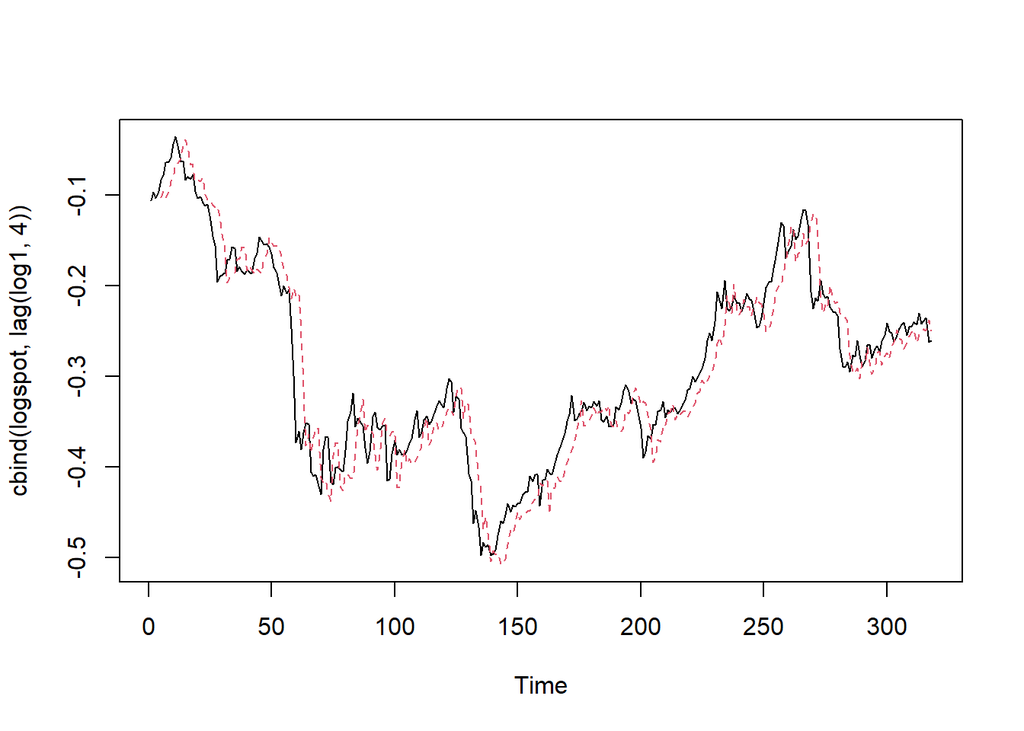

```r
matplot(y = cbind(logspot, lag(log1,4)), type = "l", xlab = "Time")
```

```r
result = lm(logspot ~ lag(log1, 4))
summary(result)
```

```
##
## Call:
## lm(formula = logspot ~ lag(log1, 4))
##
## Residuals:
##       Min        1Q    Median        3Q       Max
## -0.158243 -0.013976  0.004571  0.021201  0.078841
##
## Coefficients:
##               Estimate Std. Error t value Pr(>|t|)
## (Intercept)  -0.022437   0.005523  -4.062 6.15e-05 ***
## lag(log1, 4)  0.911680   0.017722  51.443  < 2e-16 ***
## ---
## Signif. codes:  0 '***' 0.001 '**' 0.01 '*' 0.05 '.' 0.1 ' ' 1
##
## Residual standard error: 0.03402 on 312 degrees of freedom
##   (4 observations deleted due to missingness)
## Multiple R-squared:  0.8945, Adjusted R-squared:  0.8942
## F-statistic:  2646 on 1 and 312 DF,  p-value: < 2.2e-16
```

We get the estimated equation: $s_t = -0.0224 + 0.9117 f_{t-4}+u_t$. Now, we can specify the following VECM model: $\Delta \gamma_t = \alpha(s_t-0.9117 f_{t-4}+0.0224)+v_t$

We can use Johansen test to check the the null hypothesis that the residual is I(1), which means no cointegration. The alternative hypothesis: residual is I(0), which means cointegration exists.

Johansen test

```r
d1 = data.frame(logspot, lag(log1,4))
jotest<- ca.jo(d1, ecdet = "none", spec = "transitory", K=2)
summary(jotest)
```

```
##
## ######################
## # Johansen-Procedure #
## ######################
##
## Test type: maximal eigenvalue statistic (lambda max) , with linear trend
##
## Eigenvalues (lambda):
## [1] 0.36208268 0.01607982
##
## Values of teststatistic and critical values of test:
##
##            test 10pct  5pct  1pct
## r <= 1 |   5.06  6.50  8.18 11.65
## r = 0  | 140.26 12.91 14.90 19.19
##
## Eigenvectors, normalised to first column:
## (These are the cointegration relations)
##
##                 logspot.l1 lag.log1..4..l1
## logspot.l1        1.000000       1.0000000
## lag.log1..4..l1  -0.983142       0.4777876
##
## Weights W:
## (This is the loading matrix)
##
##                 logspot.l1 lag.log1..4..l1
## logspot.d      0.001148791   -0.0133016834
## lag.log1..4..d 0.321374152   -0.0007483464
```

Since the test statisitic of r=0 is 140.26, we are able to reject the r=0 null hypothesis, this suggests that $f_{t-4}$ the lagged 1 month forward rate is cointegrated with the $s_t$ spot exchange rate.

We can now estimate the bivariate system of VECM, which is listed below

$$\begin{pmatrix}
\Delta s_{t} \\
\Delta f_{t-4}
\end{pmatrix}
=
\begin{pmatrix}
\alpha_1 \\
\alpha_2
\end{pmatrix}
(s_t-0.9117 f_{t-4}+0.0224) +
\begin{pmatrix}
v_{1,t} \\
v_{2,t}
\end{pmatrix}$$
First, we estimate the equation for $\Delta s_t$, which is $\Delta s_t = \alpha_1(s_t-0.9117 f_{t-4}+0.0224)+v_{1t}$

```r
cointegrated = logspot- lag(log1, 4)*summary(result)$coefficients[2,'Estimate']-summary(result)$coefficients[1,'Estimate']
cointegrated = cointegrated[-1]
result1 = lm(dlogspot ~ cointegrated)
summary(result1)
```

```
##
## Call:
## lm(formula = dlogspot ~ cointegrated)
##
## Residuals:
##       Min        1Q    Median        3Q       Max
## -0.059131 -0.006256  0.001410  0.007360  0.047979
##
## Coefficients:
##                Estimate Std. Error t value Pr(>|t|)
## (Intercept)  -0.0005224  0.0008011  -0.652    0.515
## cointegrated  0.2315683  0.0236223   9.803   <2e-16 ***
## ---
## Signif. codes:  0 '***' 0.001 '**' 0.01 '*' 0.05 '.' 0.1 ' ' 1
##
## Residual standard error: 0.0142 on 312 degrees of freedom
##   (3 observations deleted due to missingness)
## Multiple R-squared:  0.2355, Adjusted R-squared:  0.233
## F-statistic:  96.1 on 1 and 312 DF,  p-value: < 2.2e-16
```

$\alpha_1 = 0.2316$ Finally, we estimate the equation for $\Delta f_{t-4}$, which is $\Delta f_{t-4} = \alpha_2(s_t-0.9117 f_{t-4}+0.0224)+v_{2t}$

```r
result2 = lm(diff(lag(log1,4)) ~ cointegrated)
summary(result2)
```

```
##
## Call:
## lm(formula = diff(lag(log1, 4)) ~ cointegrated)
##
## Residuals:
##       Min        1Q    Median        3Q       Max
## -0.075867 -0.005983  0.002078  0.009628  0.052112
##
## Coefficients:
##                Estimate Std. Error t value Pr(>|t|)
## (Intercept)  -0.0004645  0.0009191  -0.505    0.614
## cointegrated  0.0379854  0.0270984   1.402    0.162
##
## Residual standard error: 0.01626 on 311 degrees of freedom
##   (4 observations deleted due to missingness)
## Multiple R-squared:  0.006278,   Adjusted R-squared:  0.003083
## F-statistic: 1.965 on 1 and 311 DF,  p-value: 0.162
```

$\alpha_2 = 0.0380$ Therefore, the estiamted bivariate VECM is
$$\begin{pmatrix}
\Delta s_{t} \\
\Delta f_{t-4}
\end{pmatrix}
=
\begin{pmatrix}
0.2316 \\
0.0380
\end{pmatrix}
(s_t-0.9117 f_{t-4}+0.0224)$$